# Weight Lifting Exercise

Jose Vicente Carrasquero Aumaitre

September 27, 2015

Using devices such as Jawbone Up, Nike FuelBand, and Fitbit it is now possible to collect a large amount of data about personal activity relatively inexpensively. These type of devices are part of the quantified self movement – a group of enthusiasts who take measurements about themselves regularly to improve their health, to find patterns in their behavior, or because they are tech geeks. One thing that people regularly do is quantify how much of a particular activity they do, but they rarely quantify how well they do it. In this project, your goal will be to use data from accelerometers on the belt, forearm, arm, and dumbell of 6 participants. They were asked to perform barbell lifts correctly and incorrectly in 5 different ways.

We begin installing needed packages and loading libraries. We include Random Forest for classification and regression, Regressive Partitioning and Regression Trees and Decision Tree plot. We set seed to guarantee reproduceability

```r
library(caret)
library(randomForest)
```

```r
library(rpart)
library(rpart.plot)
set.seed(1234)
```

Let’s create subtraining and subtesting datasets

```r
subsamples <- createDataPartition(y=trainingset$classe, p=0.60, list=FALSE)
subTraining <- trainingset[subsamples, ]
subTesting <- trainingset[-subsamples, ]
```

Bar Plot of levels of the variable classe within the subTraining data set and trining the Model 1

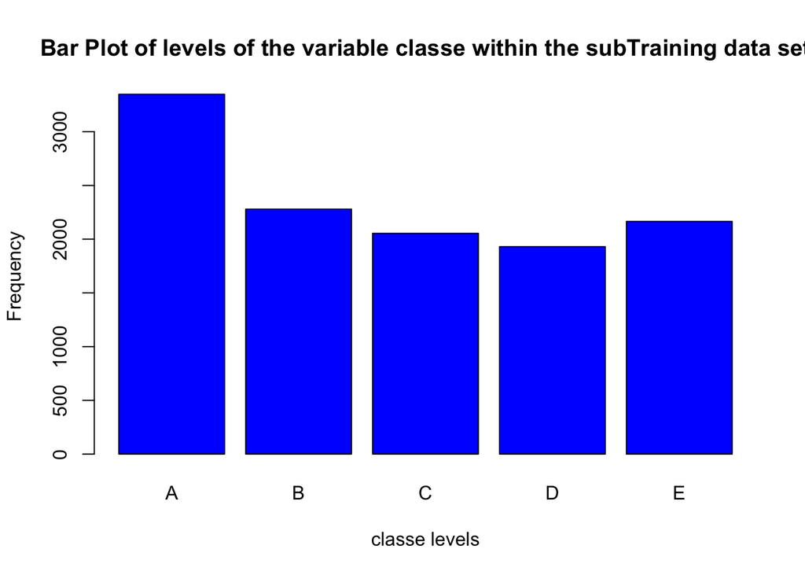

```r
plot(subTraining$classe, col="blue", main="Bar Plot of levels of the variable classe within the subTraining data set", xlab="classe levels", ylab="Frequency")
```

```r
model1 <- rpart(classe ~ ., data=subTraining, method="class")
```

Applying the prediction process with model 1 and plotting of the Decision Tree

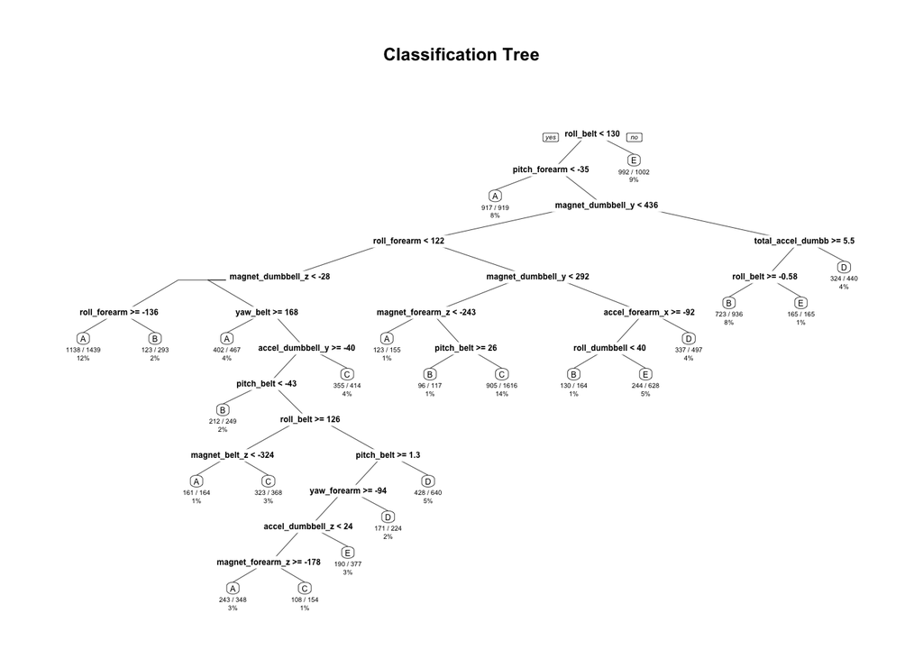

```r
prediction1 <- predict(model1, subTesting, type = "class")

rpart.plot(model1, main="Classification Tree", extra=102, under=TRUE, faclen=0)
```

Running the Confusion Matrix for Prediction 1

```r
confusionMatrix(prediction1, subTesting$classe)
```

```
## Confusion Matrix and Statistics
##
##           Reference
## Prediction    A    B    C    D    E
##          A 1980  212   21   72   31
##          B   85  862   72   90   98
##          C   56  153 1086  209  175
##          D   71  101  110  823   89
##          E   40  190   79   92 1049
##
## Overall Statistics
##
##                Accuracy : 0.7392
##                  95% CI : (0.7294, 0.7489)
##     No Information Rate : 0.2845
##     P-Value [Acc > NIR] : < 2.2e-16
##
##                   Kappa : 0.6699
##  Mcnemar's Test P-Value : < 2.2e-16
##
## Statistics by Class:
##
##                      Class: A Class: B Class: C Class: D Class: E
## Sensitivity            0.8871   0.5679   0.7939   0.6400   0.7275
## Specificity            0.9401   0.9455   0.9085   0.9434   0.9374
## Pos Pred Value         0.8549   0.7142   0.6468   0.6893   0.7234
## Neg Pred Value         0.9544   0.9012   0.9543   0.9304   0.9386
## Prevalence             0.2845   0.1935   0.1744   0.1639   0.1838
## Detection Rate         0.2524   0.1099   0.1384   0.1049   0.1337
## Detection Prevalence   0.2952   0.1538   0.2140   0.1522   0.1848
## Balanced Accuracy      0.9136   0.7567   0.8512   0.7917   0.8324
```

Creating and testing Model 2 by using Random Forest and subtesting data set

```r
model2 <- randomForest(classe ~. , data=subTraining, method="class")

prediction2 <- predict(model2, subTesting, type = "class")

confusionMatrix(prediction2, subTesting$classe)
```

```
## Confusion Matrix and Statistics
##
##           Reference
## Prediction    A    B    C    D    E
##          A 2231   12    0    0    0
##          B    0 1501    9    0    0
##          C    0    5 1354   22    2
##          D    1    0    5 1262    2
##          E    0    0    0    2 1438
##
## Overall Statistics
##
##                Accuracy : 0.9924
##                  95% CI : (0.9902, 0.9942)
##     No Information Rate : 0.2845
##     P-Value [Acc > NIR] : < 2.2e-16
##
##                   Kappa : 0.9903
##  Mcnemar's Test P-Value : NA
##
## Statistics by Class:
##
##                      Class: A Class: B Class: C Class: D Class: E
## Sensitivity            0.9996   0.9888   0.9898   0.9813   0.9972
## Specificity            0.9979   0.9986   0.9955   0.9988   0.9997
## Pos Pred Value         0.9947   0.9940   0.9790   0.9937   0.9986
## Neg Pred Value         0.9998   0.9973   0.9978   0.9964   0.9994
## Prevalence             0.2845   0.1935   0.1744   0.1639   0.1838
## Detection Rate         0.2843   0.1913   0.1726   0.1608   0.1833
## Detection Prevalence   0.2859   0.1925   0.1763   0.1619   0.1835
## Balanced Accuracy      0.9987   0.9937   0.9926   0.9901   0.9985
```